# whatTheHedge

Rohit Tolawat

6/19/2020

```
## Classes 'data.table' and 'data.frame':   244 obs. of  6 variables:
##  $ Record.number                    : int  1 2 3 4 5 6 7 8 9 10 ...
##  $ Year                             : int  2000 2000 2000 2000 2000 2000 2000 2000 2000 2000 ...
##  $ Month                            : Factor w/ 12 levels "April","August",..: 5 4 8 1 9 7 6 2 12 11 ...
##  $ dateNumber                       : Date, format: "2000-01-01" "2000-02-01" ...
##  $ totalConsumptioninMillionOfGallon: num  1495 1435 1574 1553 1609 ...
##  $ costPerGallon                    : num  0.72 0.75 0.77 0.76 0.73 0.71 0.77 0.8 0.87 0.9 ...
##  - attr(*, ".internal.selfref")=<externalptr>
```

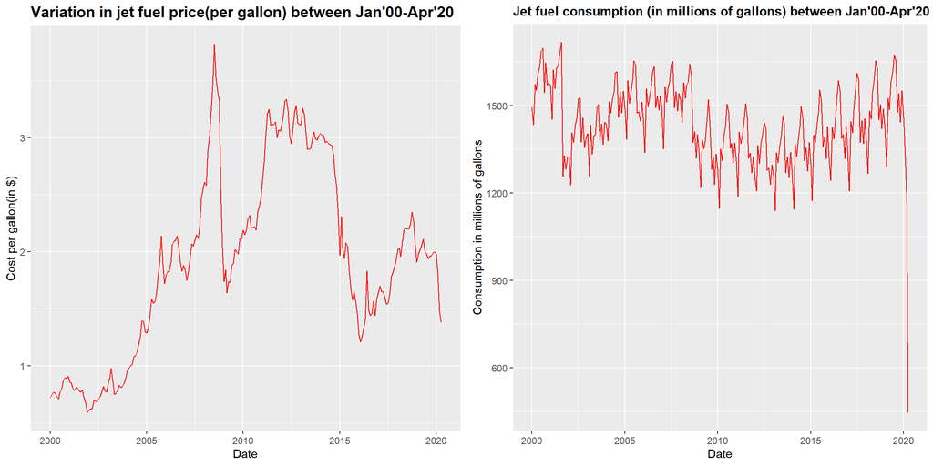

```r
pacman::p_load(caret, data.table, ggplot2,gridExtra)
knitr::opts_chunk$set(echo = FALSE, fig.width=12, fig.height=6, fig.path = 'Figs/')
options(digits = 3)
```

#Insights corner: While per gallon price of the jet fuel shot at its peak after the 2007 financial crisis, it can be noted that the commodity price is volatile with high fluctuations. To eliminate this volatility in the price, we are trying to analyze the impact of hedging. #Surprisingly, the consumption plot shows a cyclic pattern of low and high consumption. Let’s park its analysis for some other day and time.

```
## [1] "Mean value of jet fuel per gallon (Jan'00-Dec'09) =  1.49"
```

```
## [1] "Mean value of jet fuel per gallon (Jan'05-Dec'09) =  2.13"
```

```
## [1] "Mean value of jet fuel per gallon (Jan'09-Dec'09) =  2.24"
```

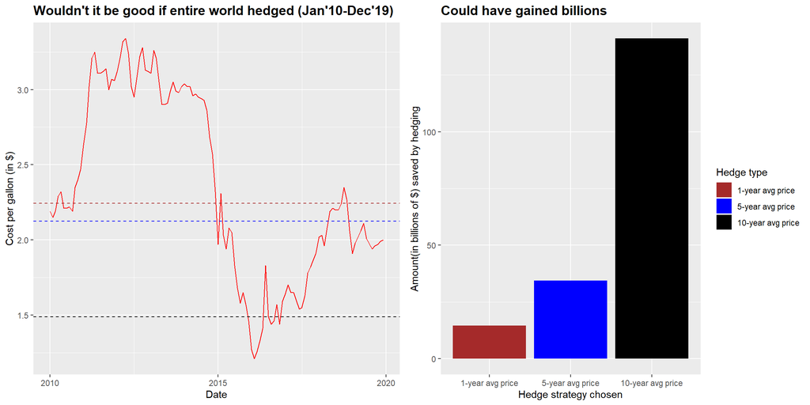

#Insights corner: Hedging would have worked wonders, wouldn’t it ? After all, we are saving billions of dollars by by hedging onto the average price from the past.

```
## [1] "Mean value of jet fuel per gallon (Jan'05-Dec'14) =  2.5"
```

```
## [1] "Mean value of jet fuel per gallon (Jan'10-Dec'14) =  2.87"
```

```
## [1] "Mean value of jet fuel per gallon (Jan'14-Dec'14) =  2.86"
```

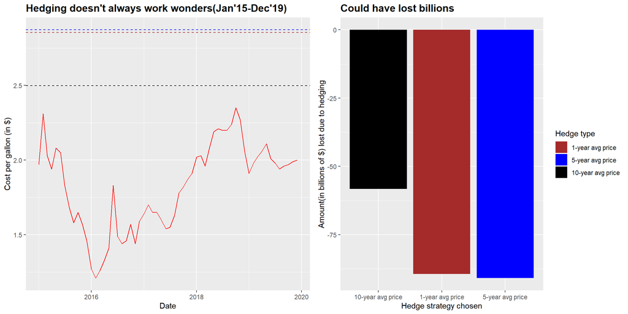

#Insights corner: Just when we thought that we really have an amazing tool to counter the volatility, we come across the above grahps. In case markets fall and jet fuel prices shoot below the hedge, we pay more than the market value of the commodity.